# From Conditional Mean to Regression

Author

Statistics for Business

Published

October 28, 2025

In this lesson, we will explore the fundamental connection between **conditional expectation** and **regression analysis**. We’ll demonstrate how the regression function $E(Y|X) = f(X)$ naturally emerges from the concept of conditional probability and conditional expectation.

1. **Joint, Marginal, and Conditional Probabilities**
2. **Conditional Expectation**: $E(Y|X=x) = \sum_y y \cdot P(Y=y|X=x)$
3. **Regression Decomposition**: $Y = E(Y|X) + \varepsilon$
4. **The regression function as the best predictor**

# 1 Loading and Exploring the Data

Let’s start by loading our wage-education dataset and creating an initial visualization.

```r
# Load the wage-education data
wage_data <- read_excel("wageedu.xlsx", sheet = "Sheet1")
colnames(wage_data) <- c("Wage", "Education")

# Display first few rows
head(wage_data, 10)
```

```
# A tibble: 10 × 2
    Wage Education
   <dbl>     <dbl>
 1  308          6
 2  308          6
 3  308          8
 4  308          8
 5  326.         6
 6  326.         6
 7  326.         8
 8  326.         8
 9  326.         8
10  326.        12
```

```r
# Summary statistics
summary(wage_data)
```

```
      Wage          Education
 Min.   : 308.0   Min.   : 6.0
 1st Qu.: 731.0   1st Qu.:12.0
 Median :1123.0   Median :16.0
 Mean   : 881.3   Mean   :13.7
 3rd Qu.:1123.0   3rd Qu.:16.0
 Max.   :1123.0   Max.   :16.0
```

```r
#Total observations
nrow(wage_data)
```

```
[1] 100
```

```r
#Unique wage levels,
unique(wage_data$Wage)
```

```
[1]  308.0  326.5  731.0 1123.0
```

```r
#Unique education levels
unique(wage_data$Education)
```

```
[1]  6  8 12 16
```

# 2 Visualization: Wage vs Education

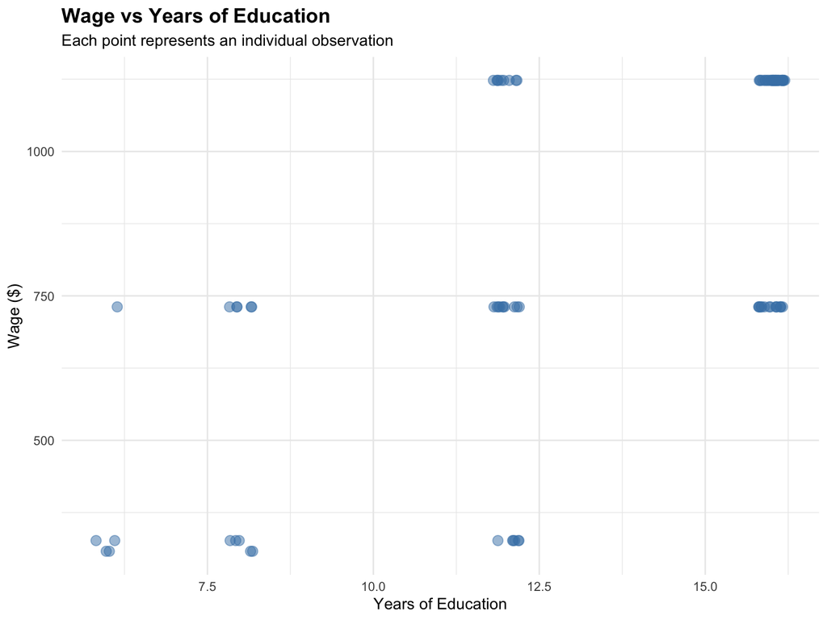

```r
# Create scatter plot with jittering for better visibility
ggplot(wage_data, aes(x = Education, y = Wage)) +
  geom_point(alpha = 0.5, size = 3, color = "steelblue",
             position = position_jitter(width = 0.2, height = 0)) +
  labs(title = "Wage vs Years of Education",
       x = "Years of Education",
       y = "Wage ($)",
       subtitle = "Each point represents an individual observation") +
  theme_minimal() +
  theme(plot.title = element_text(size = 14, face = "bold"))
```

We’ve visualized the data using a scatter plot. Now let’s represent the data in a tabular format to understand the joint distribution of wages and education levels.

```r
# Create contingency table
cont_table <- table(wage_data$Education, wage_data$Wage)
colnames(cont_table) <- paste("Wage", colnames(cont_table))
rownames(cont_table) <- paste("Educ", rownames(cont_table))

# Display the contingency table with column and row sums
cont_table_df <- as.data.frame.matrix(cont_table)
cont_table_df <- cont_table_df %>%
  mutate(Total = rowSums(.)) %>%
  rbind(Total = colSums(.))
kable(cont_table_df,
      caption = "Contingency Table: Counts of (Education, Wage)",
      col.names = c("Wage 308", "Wage 326.5", "Wage 731", "Wage 1123", "Total")) %>%
  kable_styling(bootstrap_options = c("striped", "hover"))
```

Contingency Table: Counts of (Education, Wage)

|  | Wage 308 | Wage 326.5 | Wage 731 | Wage 1123 | Total |
| --- | --- | --- | --- | --- | --- |
| Educ 6 | 2 | 2 | 1 | 0 | 5 |
| Educ 8 | 2 | 3 | 5 | 0 | 10 |
| Educ 12 | 0 | 6 | 10 | 9 | 25 |
| Educ 16 | 0 | 0 | 15 | 45 | 60 |
| Total | 4 | 11 | 31 | 54 | 100 |

# 3 Probability Calculations

Now, let’s compute the joint, marginal, and conditional probabilities from our contingency table. The idea here is to understand how the distribution of wages changes with different education levels. One way to think about this is to consider the conditional probability of wage given education. We will also look at statistical independence between the two variables.

## 3.1 Joint Probabilities

The **joint probability** $P(X=x, Y=y)$ represents the probability that education equals $x$ AND wage equals $y$:

$$P(X=x, Y=y) = \frac{n(x,y)}{n_{total}}$$

where $n(x,y)$ is the number of observations with education $x$ and wage $y$.

```r
# Calculate joint probabilities
n_total <- nrow(wage_data)
joint_prob <- cont_table / n_total

# Display joint probability table
joint_prob_df <- as.data.frame.matrix(joint_prob)
joint_prob_df <- round(joint_prob_df, 4)

kable(joint_prob_df,
      caption = "Joint Probabilities: P(Education, Wage)") %>%
  kable_styling(bootstrap_options = c("striped", "hover"))
```

Joint Probabilities: P(Education, Wage)

|  | Wage 308 | Wage 326.5 | Wage 731 | Wage 1123 |
| --- | --- | --- | --- | --- |
| Educ 6 | 0.02 | 0.02 | 0.01 | 0.00 |
| Educ 8 | 0.02 | 0.03 | 0.05 | 0.00 |
| Educ 12 | 0.00 | 0.06 | 0.10 | 0.09 |
| Educ 16 | 0.00 | 0.00 | 0.15 | 0.45 |

## 3.2 Marginal Probabilities

The **marginal probability** is the probability of a single variable regardless of the other variable:

- $P(X=x) = \sum_y P(X=x, Y=y)$ (marginal probability of education)
- $P(Y=y) = \sum_x P(X=x, Y=y)$ (marginal probability of wage)

```r
# Calculate marginal probabilities
marginal_educ <- rowSums(joint_prob)  # P(X=x)
marginal_wage <- colSums(joint_prob)  # P(Y=y)

# Display marginal probabilities for Education
marginal_educ_df <- data.frame(
  Education = c(6, 8, 12, 16),
  `P(Education)` = round(marginal_educ, 4)
)

kable(marginal_educ_df,
      caption = "Marginal Probabilities: P(Education = x)",
      col.names = c("Education (years)", "P(Education)")) %>%
  kable_styling(bootstrap_options = c("striped", "hover"), full_width = FALSE)
```

Marginal Probabilities: P(Education = x)

|  | Education (years) | P(Education) |
| --- | --- | --- |
| Educ 6 | 6 | 0.05 |
| Educ 8 | 8 | 0.10 |
| Educ 12 | 12 | 0.25 |
| Educ 16 | 16 | 0.60 |

```r
# Display marginal probabilities for Wage
marginal_wage_df <- data.frame(
  Wage = c(308, 326.5, 731, 1123),
  `P(Wage)` = round(marginal_wage, 4)
)

kable(marginal_wage_df,
      caption = "Marginal Probabilities: P(Wage = y)",
      col.names = c("Wage ($)", "P(Wage)")) %>%
  kable_styling(bootstrap_options = c("striped", "hover"), full_width = FALSE)
```

Marginal Probabilities: P(Wage = y)

|  | Wage ($) | P(Wage) |
| --- | --- | --- |
| Wage 308 | 308.0 | 0.04 |
| Wage 326.5 | 326.5 | 0.11 |
| Wage 731 | 731.0 | 0.31 |
| Wage 1123 | 1123.0 | 0.54 |

## 3.3 Conditional Probabilities

The **conditional probability** $P(Y=y|X=x)$ represents the probability that wage equals $y$ given that education equals $x$:

$$P(Y=y|X=x) = \frac{P(X=x, Y=y)}{P(X=x)}$$

This tells us the distribution of wages for each education level.

```r
# Calculate conditional probabilities P(Wage|Education)
cond_prob <- joint_prob / marginal_educ

# Display conditional probability table
cond_prob_df <- as.data.frame.matrix(cond_prob)
cond_prob_df <- round(cond_prob_df, 4)

kable(cond_prob_df,
      caption = "Conditional Probabilities: P(Wage | Education)") %>%
  kable_styling(bootstrap_options = c("striped", "hover"))
```

Conditional Probabilities: P(Wage | Education)

|  | Wage 308 | Wage 326.5 | Wage 731 | Wage 1123 |
| --- | --- | --- | --- | --- |
| Educ 6 | 0.4 | 0.40 | 0.20 | 0.00 |
| Educ 8 | 0.2 | 0.30 | 0.50 | 0.00 |
| Educ 12 | 0.0 | 0.24 | 0.40 | 0.36 |
| Educ 16 | 0.0 | 0.00 | 0.25 | 0.75 |

```r
# Verify each row sums to 1
row_sums <- round(rowSums(cond_prob), 4)
cat("\nRow sums (should all be 1):", paste(row_sums, collapse = ", "))
```

```
Row sums (should all be 1): 1, 1, 1, 1
```

let’s visualize the conditional distribution of wage given education levels using faceted bar plots.

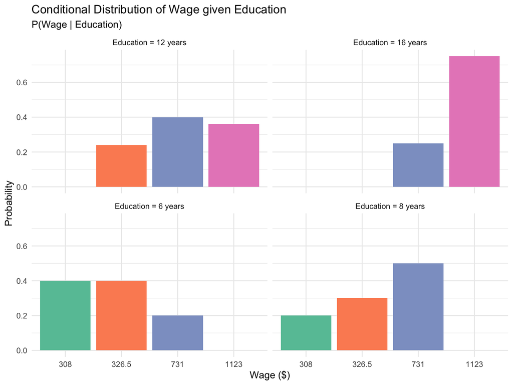

Conditional probabilities provide insights into how wage distributions vary with education levels. For example, as education increases, the probability of higher wages tends to increase, indicating a positive relationship between education and wage.

Moreover, we can check for statistical independence between education and wage. If they were independent, we would have:

$$P(Y=y|X=x) = P(Y=y)$$
We can alos express this as:

$$P(X=x, Y=y) = P(X=x) \cdot P(Y=y)$$
Hence, if education and wage are independent, the conditional probabilities should equal the marginal probabilities of wage for all education levels.

Let’s compare the conditional probabilities with the marginal probabilities of wage to assess independence.

```r
# Compare conditional probabilities with marginal probabilities
independence_check <- data.frame(
  Wage = wages_vals,
  `P(Wage)` = round(marginal_wage, 4)
)

# Let's add conditional probabilities for each education level
for (i in 1:length(education_vals)) {
  independence_check <- cbind(independence_check,
                              round(cond_prob[i, ], 4))
  colnames(independence_check)[ncol(independence_check)] <- paste("P(Wage | Educ =", education_vals[i], ")")
}

independence_check
```

```
             Wage P.Wage. P(Wage | Educ = 6 ) P(Wage | Educ = 8 )
Wage 308    308.0    0.04                 0.4                 0.2
Wage 326.5  326.5    0.11                 0.4                 0.3
Wage 731    731.0    0.31                 0.2                 0.5
Wage 1123  1123.0    0.54                 0.0                 0.0
           P(Wage | Educ = 12 ) P(Wage | Educ = 16 )
Wage 308                   0.00                 0.00
Wage 326.5                 0.24                 0.00
Wage 731                   0.40                 0.25
Wage 1123                  0.36                 0.75
```

The final concept related to conditional probabilities is Bayes’ Theorem, which allows us to reverse conditional probabilities, which can be expressed as

$$P(X=x|Y=y) = \frac{P(Y=y|X=x) \cdot P(X=x)}{P(Y=y)}$$

## 3.4 Conditional Expectation

Before jumping into conditional expectation, let’s summarize what we’ve done so far:

1. Calculated the **joint probabilities** $P(X,Y)$ from the data.
2. Derived the **marginal probabilities** $P(X)$ and $P(Y)$.
3. Computed the **conditional probabilities** $P(Y|X)$ to understand how wage distributions change with education levels.

What comes next is to compute the **conditional expectation** of wage given education, which forms the basis of regression analysis.

But first, what’s “expectation” in this context? Expectation (or expected value) is the weighted average of all possible outcomes, where each outcome is weighted by its probability. Here is a quick refresher:

- For a discrete random variable $Y$ with possible values $y_1, y_2, \ldots, y_k$ and corresponding probabilities $P(Y=y_i)$, the expectation is:
  $$E(Y) = \sum_{i=1}^{k} y_i \cdot P(Y=y_i)$$
- Similarly, the **conditional expectation** $E(Y|X=x)$ is the expected value of $Y$ given that $X$ takes on a specific value $x$.

In our context, the **conditional expectation** $E(Y|X=x)$ is the expected (mean) wage for a given education level:

$$E(Y|X=x) = \sum_y y \cdot P(Y=y|X=x)$$

This is the average wage we expect for someone with education level $x$.

```r
# Calculate conditional expectations
wages <- c(308, 326.5, 731, 1123)
cond_exp <- numeric(4)
education_levels <- c(6, 8, 12, 16)

# Calculate E(Y|X) for each education level
for (i in 1:4) {
  cond_exp[i] <- sum(wages * cond_prob[i, ])
}

# Create summary table
cond_exp_df <- data.frame(
  Education = education_levels,
  Conditional_Mean = round(cond_exp, 2)
)

kable(cond_exp_df,
      caption = "Conditional Expectation: E(Wage | Education)",
      col.names = c("Education (years)", "E(Wage given Education)")) %>%
  kable_styling(bootstrap_options = c("striped", "hover"), full_width = FALSE)
```

Conditional Expectation: E(Wage | Education)

| Education (years) | E(Wage given Education) |
| --- | --- |
| 6 | 400.00 |
| 8 | 525.05 |
| 12 | 775.04 |
| 16 | 1025.00 |

```r
# Show detailed calculation for Education = 12
educ_12_idx <- which(education_levels == 12)
cat("E(Wage | Educ=12) = ")
```

```
E(Wage | Educ=12) =
```

```r
for (j in 1:length(wages)) {
  if (j > 1) cat(" + ")
  cat(sprintf("%.0f × %.4f", wages[j], cond_prob[educ_12_idx, j]))
}
```

```
308 × 0.0000 + 326 × 0.2400 + 731 × 0.4000 + 1123 × 0.3600
```

```r
cat(sprintf("\n                  = %.2f\n", cond_exp[educ_12_idx]))
```

```
                  = 775.04
```

# 4 From Conditional Mean to Regression

The conditional expectation $E(Y|X)$ defines the **regression function**. We can write:

$$Y = E(Y|X) + \varepsilon$$

where:

- $E(Y|X) = f(X)$ is the systematic component (regression function)
- $\varepsilon$ is the random error with $E(\varepsilon|X) = 0$.

The error term $\varepsilon$ captures the deviation of actual wages from the expected wage given education.

But, first expressed the conditional mean as the function of education:

$$E(Wage | Education) = f(Education) = \beta_1 + \beta_2 \cdot Education$$

where $\beta_1$ is the intercept and $\beta_2$ is the slope of the regression line.

Here is the visualization of the regression function:

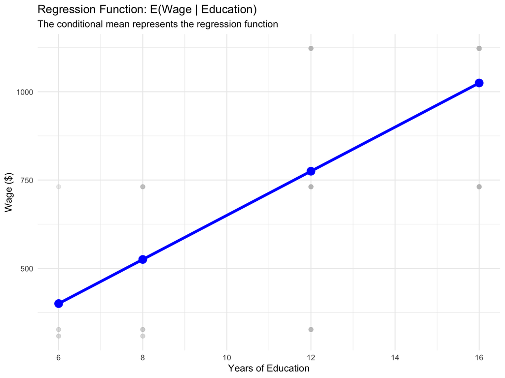

Here we show several error terms for individual observations on the same plot

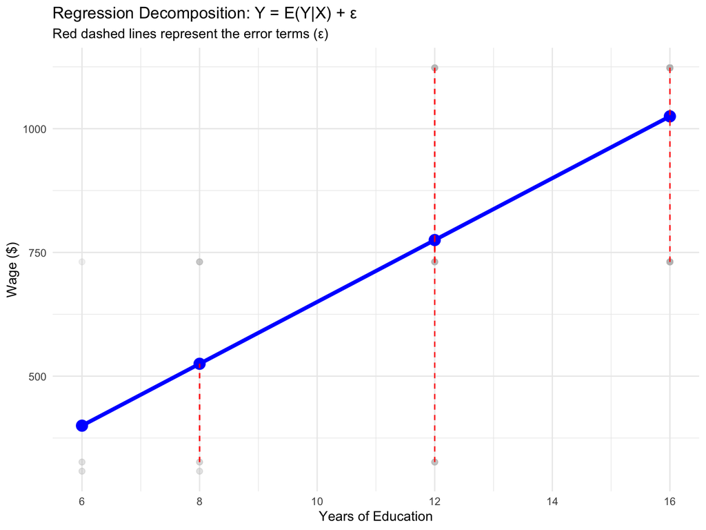

We can also see the regression decomposition in a tabular format:

```r
# Add conditional expectations to the original data
wage_data$Cond_Exp <- NA
for (i in 1:nrow(wage_data)) {
  educ_idx <- which(education_levels == wage_data$Education[i])
  wage_data$Cond_Exp[i] <- cond_exp[educ_idx]
}

# Calculate residuals
wage_data$Residual <- wage_data$Wage - wage_data$Cond_Exp

# Display first 10 observations with decomposition
decomp_display <- wage_data[1:10, ] %>%
  mutate(across(c(Cond_Exp, Residual), ~round(., 2)))

kable(decomp_display,
      caption = "Regression Decomposition: Y = E(Y|X) + ε",
      col.names = c("Wage (Y)", "Education (X)", "E(Y given X)", "ε")) %>%
  kable_styling(bootstrap_options = c("striped", "hover"))
```

Regression Decomposition: Y = E(Y|X) + ε

| Wage (Y) | Education (X) | E(Y given X) | ε |
| --- | --- | --- | --- |
| 308.0 | 6 | 400.00 | -92.00 |
| 308.0 | 6 | 400.00 | -92.00 |
| 308.0 | 8 | 525.05 | -217.05 |
| 308.0 | 8 | 525.05 | -217.05 |
| 326.5 | 6 | 400.00 | -73.50 |
| 326.5 | 6 | 400.00 | -73.50 |
| 326.5 | 8 | 525.05 | -198.55 |
| 326.5 | 8 | 525.05 | -198.55 |
| 326.5 | 8 | 525.05 | -198.55 |
| 326.5 | 12 | 775.04 | -448.54 |

## 4.1 Verifying Key Properties

Let’s first discuss why E(ε|X) = 0. If we take the conditional expectation of both sides of the regression decomposition:

$$Y = \beta_1 + \beta_2.X+ \varepsilon$$
Hence

$$E(Y|X) = E(\beta_1 + \beta_2.X + \varepsilon | X)$$
Using the linearity of expectation and the fact that $\beta_1$ and $\beta_2.X$ are functions of $X$:

$$E(Y|X) = \beta_1 + \beta_2.X + E(\varepsilon | X)$$

Let’s verify that $E(\varepsilon|X) = 0$, which is a fundamental property of regression:

```r
# Calculate E(epsilon|X) for each education level
residual_means <- wage_data %>%
  group_by(Education) %>%
  summarise(
    `Mean_Residual` = mean(Residual),
    `SD_Residual` = sd(Residual),
    `n` = n()
  ) %>%
  mutate(across(c(Mean_Residual, SD_Residual), ~round(., 6)))

kable(residual_means,
      caption = "Mean and Standard Deviation of Residuals by Education Level",
      col.names = c("Education", "E(ε given X)", "SD(ε given X)", "n")) %>%
  kable_styling(bootstrap_options = c("striped", "hover"), full_width = FALSE)
```

Mean and Standard Deviation of Residuals by Education Level

| Education | E(ε given X) | SD(ε given X) | n |
| --- | --- | --- | --- |
| 6 | 0 | 185.2657 | 5 |
| 8 | 0 | 217.1954 | 10 |
| 12 | 0 | 310.6585 | 25 |
| 16 | 0 | 171.1734 | 60 |

```r
cat("\n✓ Notice that E(ε|X) ≈ 0 for all education levels (within numerical precision)")
```

```
✓ Notice that E(ε|X) ≈ 0 for all education levels (within numerical precision)
```

## 4.2 Linear Regression Comparison

Now let’s fit a linear regression and compare it with our conditional expectations:

```r
# Fit linear regression
lm_model <- lm(Wage ~ Education, data = wage_data)

# Display regression summary
summary(lm_model)
```

```
Call:
lm(formula = Wage ~ Education, data = wage_data)

Residuals:
   Min     1Q Median     3Q    Max
-448.5 -198.5   98.0   98.0  348.0

Coefficients:
            Estimate Std. Error t value Pr(>|t|)
(Intercept)   25.077     95.901   0.261    0.794
Education     62.495      6.819   9.165 7.85e-15 ***
---
Signif. codes:  0 '***' 0.001 '**' 0.01 '*' 0.05 '.' 0.1 ' ' 1

Residual standard error: 216.8 on 98 degrees of freedom
Multiple R-squared:  0.4615,    Adjusted R-squared:  0.456
F-statistic:    84 on 1 and 98 DF,  p-value: 7.849e-15
```

```r
# Get predictions from linear model
education_grid <- data.frame(Education = education_levels)
lm_predictions <- predict(lm_model, newdata = education_grid)

# Create comparison table
comparison_df <- data.frame(
  Education = education_levels,
  `Conditional_Mean` = round(cond_exp, 2),
  `Linear_Regression` = round(lm_predictions, 2),
  `Difference` = round(cond_exp - lm_predictions, 2)
)

kable(comparison_df,
      caption = "Comparison: Conditional Mean vs Linear Regression",
      col.names = c("Education", "E(Y given X)", "Linear Fit", "Difference")) %>%
  kable_styling(bootstrap_options = c("striped", "hover"), full_width = FALSE)
```

Comparison: Conditional Mean vs Linear Regression

| Education | E(Y given X) | Linear Fit | Difference |
| --- | --- | --- | --- |
| 6 | 400.00 | 400.05 | -0.05 |
| 8 | 525.05 | 525.04 | 0.01 |
| 12 | 775.04 | 775.02 | 0.02 |
| 16 | 1025.00 | 1025.00 | 0.00 |

# 5 Key Insights and Theoretical Foundation

The conditional expectation $E(Y|X)$ is the **best predictor** of $Y$ given $X$ in the sense that it minimizes the mean squared error:

$$E[(Y - g(X))^2]$$

over all possible functions $g(X)$.

More intuitively, if we want to predict wages based on education, using the conditional mean $E(Y|X)$ will yield the lowest average squared prediction error compared to any other function of $X$.

The regression function $f(X) = E(Y|X)$ has these important properties:

1. **Unbiasedness**: $E[Y - f(X)] = 0$. This means that $E(b_2)=\beta_2$ and $E(b_1)=\beta_1$
2. **Orthogonality**: $E[\varepsilon \cdot X] = 0$ This implies that the error term is uncorrelated with any of $X$. If this condition holds, then $Cov(e,X)=0$. If does not hold, then we have endogeneity and our OLS estimates will be biased and inconsistent.
3. **Minimum MSE**: $f(X)$ minimizes $E[(Y - g(X))^2]$ over all functions $g$

The linear regression model is a specific case where we assume a linear form for $f(X)$:

$$f(X) = \beta_1 + \beta_2 X$$
Linear regression assumes that $E(Y|X) = \beta_0 + \beta_1 X$, which is a **linear approximation** to the true conditional expectation.

In our example:

```r
# Test for nonlinearity
education_factor <- factor(wage_data$Education)
anova_model <- lm(Wage ~ education_factor, data = wage_data)
linear_model <- lm(Wage ~ Education, data = wage_data)

# F-test for linearity
anova_result <- anova(linear_model, anova_model)
print(anova_result)
```

```
Analysis of Variance Table

Model 1: Wage ~ Education
Model 2: Wage ~ education_factor
  Res.Df     RSS Df Sum of Sq  F Pr(>F)
1     98 4606788
2     96 4606788  2  0.022023  0      1
```

```r
f_stat <- anova_result$F[2]
p_value <- anova_result$`Pr(>F)`[2]

cat("\n")
```

```r
if (p_value < 0.05) {
  cat("✓ The F-test suggests significant nonlinearity (p < 0.05)\n")
  cat("  This confirms that E(Y|X) is not perfectly linear in X")
} else {
  cat("The F-test does not detect significant nonlinearity")
}
```

```
The F-test does not detect significant nonlinearity
```

# 6 Mathematical Derivation: From Covariance to Regression Coefficients

Let’s derive the regression coefficients using the covariance approach, which provides another perspective on the regression function.

Starting with the linear regression model:
$$Y_i = \beta_1 + \beta_2 X_i + e_i$$

Taking the covariance of both sides with X:
$$Cov(Y, X) = Cov(\beta_1 + \beta_2 X + e, X)$$

Expanding using covariance properties:
$$Cov(Y, X) = Cov(\beta_1, X) + Cov(\beta_2 X, X) + Cov(e, X)$$

Since $\beta_1$ is a constant: $Cov(\beta_1, X) = 0$ Since $\beta_2$ is a constant: $Cov(\beta_2 X, X) = \beta_2 Cov(X, X) = \beta_2 Var(X)$ By assumption: $Cov(e, X) = 0$

Therefore:
$$Cov(Y, X) = \beta_2 Var(X)$$

Solving for $\beta_2$:
$$\beta_2 = \frac{Cov(Y, X)}{Var(X)} = \frac{\sigma_{XY}}{\sigma_X^2}$$

Let’s calculate $\beta_2$ using our wage-education data:

```r
# Calculate covariance and variance
cov_xy <- cov(wage_data$Wage, wage_data$Education)
var_x <- var(wage_data$Education)

# Calculate beta_2
beta_2 <- cov_xy / var_x

cat("Cov(Wage, Education) =", round(cov_xy, 2), "\n")
```

```
Cov(Wage, Education) = 638.21
```

```r
cat("Var(Education) =", round(var_x, 2), "\n")
```

```
Var(Education) = 10.21
```

```r
cat("β₂ = Cov(Y,X)/Var(X) =", round(cov_xy, 2), "/", round(var_x, 2), "=", round(beta_2, 2), "\n")
```

```
β₂ = Cov(Y,X)/Var(X) = 638.21 / 10.21 = 62.5
```

Using the fact that the regression line passes through the mean point $(\bar{X}, \bar{Y})$:
$$\bar{Y} = \beta_1 + \beta_2 \bar{X}$$

Therefore:
$$\beta_1 = \bar{Y} - \beta_2 \bar{X} = E(Y) - \beta_2 E(X)$$

```r
# Calculate means
mean_y <- mean(wage_data$Wage)
mean_x <- mean(wage_data$Education)

# Calculate beta_1
beta_1 <- mean_y - beta_2 * mean_x

cat("E(Wage) =", round(mean_y, 2), "\n")
```

```
E(Wage) = 881.27
```

```r
cat("E(Education) =", round(mean_x, 2), "\n")
```

```
E(Education) = 13.7
```

```r
cat("β₁ = E(Y) - β₂E(X) =", round(mean_y, 2), "-", round(beta_2, 2), "×", round(mean_x, 2), "=", round(beta_1, 2), "\n")
```

```
β₁ = E(Y) - β₂E(X) = 881.27 - 62.5 × 13.7 = 25.08
```

And the final regression equation is:

```r
# Display the final equation
cat("\n### The Regression Function:\n")
```

```
### The Regression Function:
```

```r
cat("E(Y|X) =", round(beta_1, 2), "+", round(beta_2, 2), "× X\n")
```

```
E(Y|X) = 25.08 + 62.5 × X
```

```r
cat("\nOr in our context:\n")
```

```
Or in our context:
```

```r
cat("E(Wage | Education) =", round(beta_1, 2), "+", round(beta_2, 2), "× Education\n")
```

```
E(Wage | Education) = 25.08 + 62.5 × Education
```

```r
# Verify this matches our lm() results
cat("\n### Verification with lm():\n")
```

```
### Verification with lm():
```

```r
coef(lm_model)
```

```
(Intercept)   Education
   25.07666    62.49550
```

We’ve now shown two equivalent approaches to regression:

1. **Probabilistic Approach**: Starting from conditional probabilities → conditional expectation → E(Y|X)
2. **Covariance Approach**: Using the orthogonality condition Cov(e,X) = 0 → deriving β coefficients

Both lead to the same regression function, demonstrating that:

- Regression coefficients have a deep connection to conditional expectations
- The slope β₂ represents the covariance between X and Y, scaled by the variance of X
- The assumption E(e|X) = 0 is equivalent to Cov(e,X) = 0 under certain conditions

# 7 OLS Analytical Solution: Minimizing Residual Sum of Squares

In this section, we derive the regression coefficients using the **Ordinary Least Squares (OLS)** method by minimizing the Residual Sum of Squares (RSS). This provides a third perspective on regression, complementing the probabilistic and covariance approaches.

For the linear regression model:
$$y_i = \beta_1 + \beta_2 x_i + e_i$$

We want to find $\beta_1$ and $\beta_2$ that minimize the **Residual Sum of Squares**:

$$RSS = \sum_{i=1}^{n} e_i^2 = \sum_{i=1}^{n} (y_i - \beta_1 - \beta_2 x_i)^2$$

This is an optimization problem: find $(\beta_1, \beta_2)$ such that RSS is minimized.

To minimize RSS, we take partial derivatives with respect to $\beta_1$ and $\beta_2$ and set them equal to zero:

$$\frac{\partial RSS}{\partial \beta_1} = \frac{\partial}{\partial \beta_1} \sum_{i=1}^{n} (y_i - \beta_1 - \beta_2 x_i)^2$$

Using the chain rule:
$$\frac{\partial RSS}{\partial \beta_1} = 2 \sum_{i=1}^{n} (y_i - \beta_1 - \beta_2 x_i)(-1) = -2 \sum_{i=1}^{n} (y_i - \beta_1 - \beta_2 x_i)$$

Setting equal to zero:
$$\sum_{i=1}^{n} (y_i - \beta_1 - \beta_2 x_i) = 0$$

$$\frac{\partial RSS}{\partial \beta_2} = \frac{\partial}{\partial \beta_2} \sum_{i=1}^{n} (y_i - \beta_1 - \beta_2 x_i)^2$$

Using the chain rule:
$$\frac{\partial RSS}{\partial \beta_2} = 2 \sum_{i=1}^{n} (y_i - \beta_1 - \beta_2 x_i)(-x_i) = -2 \sum_{i=1}^{n} x_i(y_i - \beta_1 - \beta_2 x_i)$$

Setting equal to zero:
$$\sum_{i=1}^{n} x_i(y_i - \beta_1 - \beta_2 x_i) = 0$$

Now we have two equations from the first order conditions: the **Normal Equations**

1. $\sum_{i=1}^{n} y_i = n\beta_1 + \beta_2 \sum_{i=1}^{n} x_i$
2. $\sum_{i=1}^{n} x_i y_i = \beta_1 \sum_{i=1}^{n} x_i + \beta_2 \sum_{i=1}^{n} x_i^2$

From equation (1), dividing by $n$:
$$\bar{y} = \beta_1 + \beta_2 \bar{x}$$

Therefore:
$$\beta_1 = \bar{y} - \beta_2 \bar{x}$$

Substituting $\beta_1 = \bar{y} - \beta_2 \bar{x}$ into equation (2):
$$\sum_{i=1}^{n} x_i y_i = (\bar{y} - \beta_2 \bar{x}) \sum_{i=1}^{n} x_i + \beta_2 \sum_{i=1}^{n} x_i^2$$

Since $\sum_{i=1}^{n} x_i = n\bar{x}$:
$$\sum_{i=1}^{n} x_i y_i = n\bar{x}\bar{y} - \beta_2 n\bar{x}^2 + \beta_2 \sum_{i=1}^{n} x_i^2$$

Rearranging:
$$\sum_{i=1}^{n} x_i y_i - n\bar{x}\bar{y} = \beta_2 \left(\sum_{i=1}^{n} x_i^2 - n\bar{x}^2\right)$$

Therefore:
$$\beta_2 = \frac{\sum_{i=1}^{n} x_i y_i - n\bar{x}\bar{y}}{\sum_{i=1}^{n} x_i^2 - n\bar{x}^2}$$

## 7.1 Connecting to the Covariance Formula

Now we show that this OLS formula is equivalent to $\beta_2 = \frac{Cov(X,Y)}{Var(X)}$.

#### 7.1.0.1 Numerator:

$$\sum_{i=1}^{n} x_i y_i - n\bar{x}\bar{y} = \sum_{i=1}^{n} (x_i - \bar{x})(y_i - \bar{y})$$

**Proof**: Expanding the right side:
$$\sum_{i=1}^{n} (x_i - \bar{x})(y_i - \bar{y}) = \sum_{i=1}^{n} x_i y_i - \bar{y}\sum_{i=1}^{n} x_i - \bar{x}\sum_{i=1}^{n} y_i + n\bar{x}\bar{y}$$
$$= \sum_{i=1}^{n} x_i y_i - \bar{y}(n\bar{x}) - \bar{x}(n\bar{y}) + n\bar{x}\bar{y}$$
$$= \sum_{i=1}^{n} x_i y_i - n\bar{x}\bar{y}$$

This is the sample covariance multiplied by $(n-1)$: $(n-1) \cdot Cov(X,Y)$

And the denominator:

$$\sum_{i=1}^{n} x_i^2 - n\bar{x}^2 = \sum_{i=1}^{n} (x_i - \bar{x})^2$$

**Proof**: Expanding the right side:
$$\sum_{i=1}^{n} (x_i - \bar{x})^2 = \sum_{i=1}^{n} x_i^2 - 2\bar{x}\sum_{i=1}^{n} x_i + n\bar{x}^2$$
$$= \sum_{i=1}^{n} x_i^2 - 2\bar{x}(n\bar{x}) + n\bar{x}^2$$
$$= \sum_{i=1}^{n} x_i^2 - n\bar{x}^2$$

This is the sample variance multiplied by $(n-1)$: $(n-1) \cdot Var(X)$

$$\beta_2 = \frac{(n-1) \cdot Cov(X,Y)}{(n-1) \cdot Var(X)} = \frac{Cov(X,Y)}{Var(X)}$$

## 7.2 Numerical Verification with Our Data

Let’s verify that the OLS formula using summations gives the same result as the covariance approach:

```r
# Calculate using summation formulas
n <- nrow(wage_data)
sum_x <- sum(wage_data$Education)
sum_y <- sum(wage_data$Wage)
sum_xy <- sum(wage_data$Education * wage_data$Wage)
sum_x2 <- sum(wage_data$Education^2)

x_bar <- mean(wage_data$Education)
y_bar <- mean(wage_data$Wage)

# Calculate beta_2 using the OLS summation formula
beta_2_ols <- (sum_xy - n * x_bar * y_bar) / (sum_x2 - n * x_bar^2)

# Calculate beta_1 using the OLS formula
beta_1_ols <- y_bar - beta_2_ols * x_bar

# Display the calculations
cat("OLS Calculation using Summations:\n")
```

```
OLS Calculation using Summations:
```

```r
cat("n =", n, "\n")
```

```
n = 100
```

```r
cat("Σx =", sum_x, "\n")
```

```
Σx = 1370
```

```r
cat("Σy =", sum_y, "\n")
```

```
Σy = 88126.5
```

```r
cat("Σxy =", sum_xy, "\n")
```

```
Σxy = 1270516
```

```r
cat("Σx² =", sum_x2, "\n")
```

```
Σx² = 19780
```

```r
cat("x̄ =", round(x_bar, 2), "\n")
```

```
x̄ = 13.7
```

```r
cat("ȳ =", round(y_bar, 2), "\n\n")
```

```
ȳ = 881.27
```

```r
cat("Numerator: Σxy - nx̄ȳ =", sum_xy, "-", n, "×", round(x_bar, 2), "×", round(y_bar, 2),
    "=", round(sum_xy - n * x_bar * y_bar, 2), "\n")
```

```
Numerator: Σxy - nx̄ȳ = 1270516 - 100 × 13.7 × 881.27 = 63182.95
```

```r
cat("Denominator: Σx² - nx̄² =", sum_x2, "-", n, "×", round(x_bar^2, 2),
    "=", round(sum_x2 - n * x_bar^2, 2), "\n\n")
```

```
Denominator: Σx² - nx̄² = 19780 - 100 × 187.69 = 1011
```

```r
cat("OLS Results:\n")
```

```
OLS Results:
```

```r
cat("β₂ (OLS) =", round(beta_2_ols, 4), "\n")
```

```
β₂ (OLS) = 62.4955
```

```r
cat("β₁ (OLS) =", round(beta_1_ols, 4), "\n\n")
```

```
β₁ (OLS) = 25.0767
```

```r
# Compare with covariance approach from Section 7
cat("Comparison with Covariance Approach (Section 7):\n")
```

[output not shown]

```r
cat("β₂ (Covariance) =", round(beta_2, 4), "\n")
```

```
β₂ (Covariance) = 62.4955
```

```r
cat("β₁ (Covariance) =", round(beta_1, 4), "\n\n")
```

```
β₁ (Covariance) = 25.0767
```

```r
# Verify they are the same
cat("✓ The OLS and Covariance approaches yield identical results!\n")
```

```
✓ The OLS and Covariance approaches yield identical results!
```

# 8 Key Insight: Three Equivalent Paths to Regression

All three approaches lead to the **same regression function**, demonstrating the deep mathematical unity underlying regression analysis. Whether we think of regression as: - Estimating conditional expectations - Finding coefficients with zero error-predictor covariance - Minimizing squared prediction errors

We arrive at the same answer: **β₂ = Cov(X,Y)/Var(X)** and **β₁ = ȳ - β₂x̄**

We have demonstrated the fundamental connection between **conditional probability** and **regression**:

1. **Starting Point**: Joint distribution of $(X, Y)$
2. **Conditional Probability**: $P(Y|X) = \frac{P(X,Y)}{P(X)}$
3. **Conditional Expectation**: $E(Y|X) = \sum_y y \cdot P(Y=y|X)$
4. **Regression Function**: $E(Y|X) = f(X)$
5. **Decomposition**: $Y = E(Y|X) + \varepsilon$ where $E(\varepsilon|X) = 0$

**Key Takeaways:**

- **Regression IS conditional expectation**: The regression function $f(X)$ is precisely $E(Y|X)$
- **Optimal prediction**: $E(Y|X)$ minimizes mean squared error
- **Linear regression**: Provides the best linear approximation when $E(Y|X)$ is not linear
- **Residuals**: Have zero conditional mean by construction.

**Practical Implications:**

1. **Understanding regression**: It’s not just “fitting a line” – it’s estimating conditional expectations
2. **Model specification**: Deviations from linearity represent real features of $E(Y|X)$
3. **Prediction**: The conditional mean is the theoretically optimal point predictor.